# Week 04: Other Random Effect Structures

2020-Feb-03 (updated: 2020-02-01)

# Turtles all the way down

MLR is useful for *nested data*.

So far, we’ve considered two levels of nesting:

- Participants tested at different time points
- Participants tested at different set sizes

It’s also possible to have multiple nesting levels or other kinds of crossed nesting structures.

This is captured by the *random effect structure*.

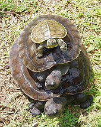

image credit: wikipedia

# 3-level nesting, part 1

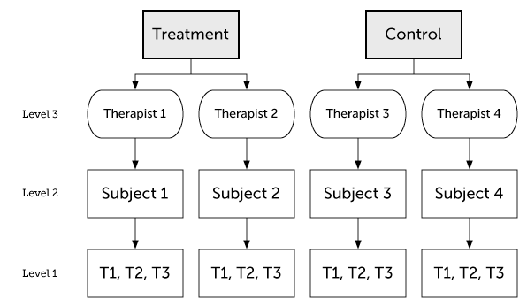

image credit: Kristoffer Magnusson

Sources of variability (random intercepts and time-slopes):

- Therapists
- Subjects

# Example: Math Active Learning

Simulated example: Testing whether a new (computer based) active learning method improves math test scores.

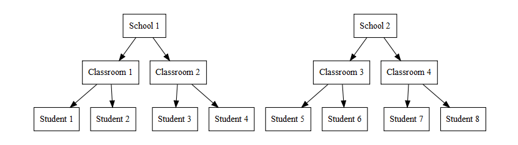

image credit: Alexander P. Demos

# Example: Math Active Learning, exploratory plot 1

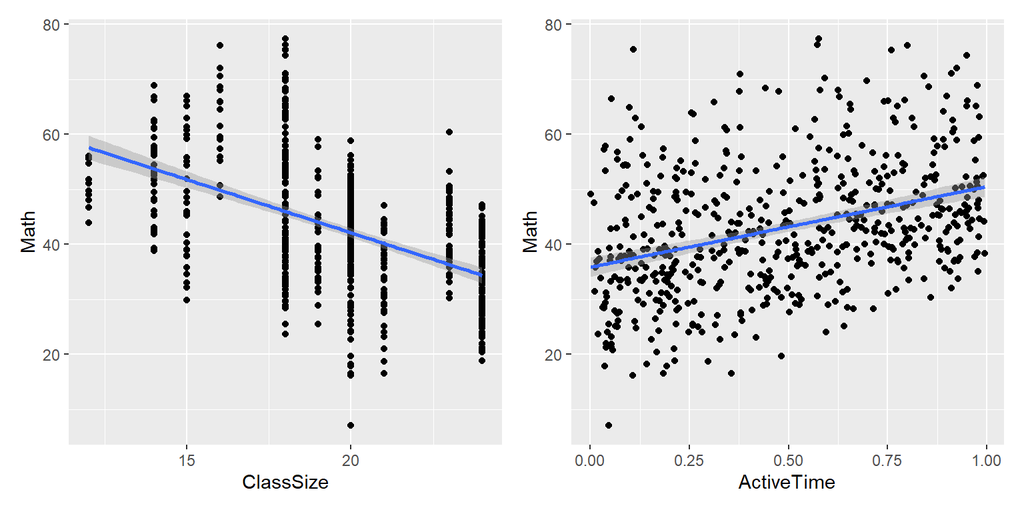

```r
math <- read.csv("../data/active_math_sim.csv") %>%
  mutate(Class = paste0(School, "cl", Classroom), #unique class ID
         ActiveTime.GM = scale(ActiveTime, scale=F), #grand-mean centered
         ClassSize.GM = scale(ClassSize, scale=F)) %>% #grand-mean centered
  group_by(School) %>%
  mutate(ClassSize.SM = scale(ClassSize, scale=F)) #school-mean centered
# plot overall relationships
p1a <- ggplot(math, aes(ClassSize, Math)) + geom_point() + geom_smooth(method = "lm")
p1b <- ggplot(math, aes(ActiveTime, Math)) + geom_point() + geom_smooth(method = "lm")
p1a + p1b # requires "patchwork" library
```

# Example: Math Active Learning, exploratory plot 2

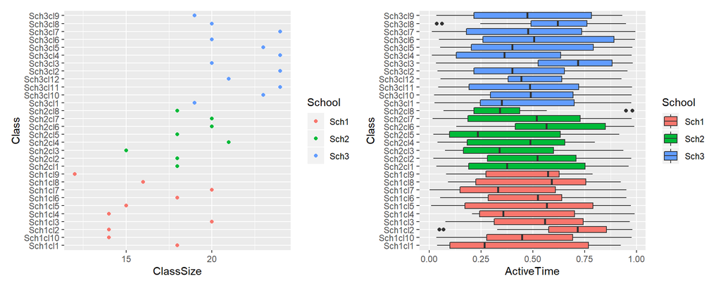

```r
p2a <- ggplot(math, aes(Class, ClassSize, color=School)) +
  geom_point() + coord_flip()
p2b <- ggplot(math, aes(Class, ActiveTime, fill=School)) +
  geom_boxplot() + coord_flip()
p2a + p2b
```

- Classes differ in size, and this is unequal across schools
- Students differ in proportion of time spent on active learning, but each class has a big (similar) range

# Example: Math Active Learning, 2-level model

```r
m1 <- lmer(Math ~ ActiveTime.GM * ClassSize.GM
          + (1 | Class),
          data=math, REML=FALSE)
kable(tidy(m1)) # requires "broom.mixed" package
```

| effect | group | term | estimate | std.error | statistic | df | p.value |
| --- | --- | --- | --- | --- | --- | --- | --- |
| fixed | NA | (Intercept) | 42.9645 | 1.5858 | 27.093 | 29.93 | 0.0000 |
| fixed | NA | ActiveTime.GM | 14.9057 | 0.6044 | 24.662 | 540.66 | 0.0000 |
| fixed | NA | ClassSize.GM | -1.8662 | 0.4805 | -3.884 | 30.05 | 0.0005 |
| fixed | NA | ActiveTime.GM:ClassSize.GM | 0.3613 | 0.1939 | 1.863 | 540.59 | 0.0630 |
| ran_pars | Class | sd__(Intercept) | 8.5091 | NA | NA | NA | NA |
| ran_pars | Residual | sd__Observation | 4.1709 | NA | NA | NA | NA |

- As we work through this example, keep an eye on the interaction between active learning time and class size.

# Example: Math Active Learning, 2-level model - plot the fit(s)

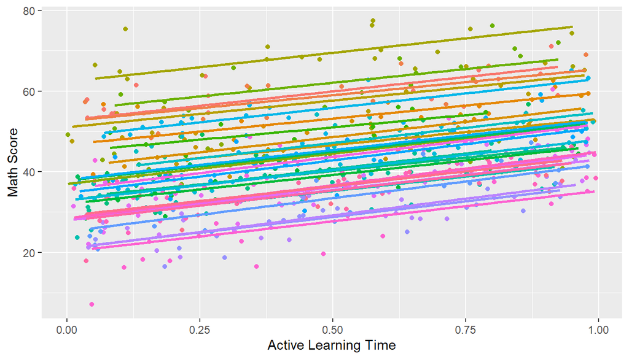

```r
ggplot(fortify(m1), aes(ActiveTime, Math, color=Class))+
  geom_point() + geom_smooth(aes(y=.fitted), method = "lm") +
  xlab("Active Learning Time") + ylab("Math Score")+
  theme(legend.position = "none")
```

Note the parallel lines:

- Our model allows classrooms to differ in math scores (random intercept)
- but not in the effect of active learning, which is assumed to be the same in all classrooms
- Maybe classes differ in how strongly active learning influences math achievement? *Add random slopes*

# Example: Math Active Learning, 2-level model, part 2

```r
m2 <- lmer(Math ~ ActiveTime.GM * ClassSize.GM
          + (1 + ActiveTime.GM | Class),
          data=math, REML=FALSE)
kable(tidy(m2))
```

| effect | group | term | estimate | std.error | statistic | df | p.value |
| --- | --- | --- | --- | --- | --- | --- | --- |
| fixed | NA | (Intercept) | 42.8612 | 1.5978 | 26.826 | 29.98 | 0.0000 |
| fixed | NA | ActiveTime.GM | 14.8927 | 1.0453 | 14.248 | 30.30 | 0.0000 |
| fixed | NA | ClassSize.GM | -1.8703 | 0.4841 | -3.864 | 30.08 | 0.0006 |
| fixed | NA | ActiveTime.GM:ClassSize.GM | 0.3329 | 0.3263 | 1.020 | 33.09 | 0.3151 |
| ran_pars | Class | sd__(Intercept) | 8.5785 | NA | NA | NA | NA |
| ran_pars | Class | sd__ActiveTime.GM | 4.7125 | NA | NA | NA | NA |
| ran_pars | Class | cor__(Intercept).ActiveTime.GM | -0.3106 | NA | NA | NA | NA |
| ran_pars | Residual | sd__Observation | 3.9162 | NA | NA | NA | NA |

- Adding `ActiveTime` random slopes substantially reduced estimated df for `ActiveTime` fixed effects
- Interaction effect is not even marginal in this model: in the first model, omitting the random slope made the corresponding fixed effect anti-conservative. Now that we have that random slope, the model can capture *random* classroom-level variation in effect of active learning instead of spuriously assigning it to class

# Example: Math Active Learning, 2-level model, part 2 - plot fit(s)

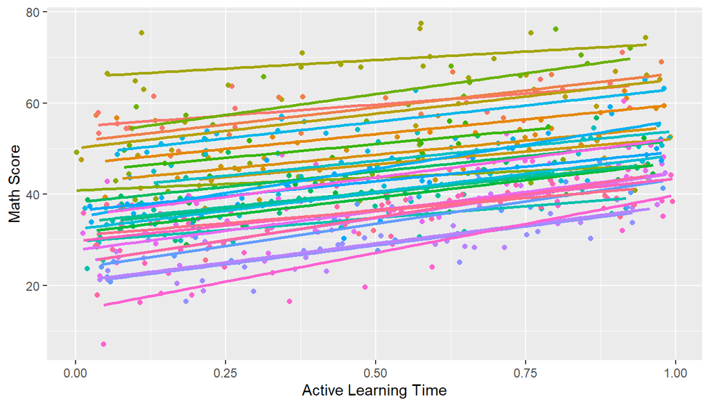

```r
ggplot(fortify(m2), aes(ActiveTime, Math, color=Class))+
  geom_point() + geom_smooth(aes(y=.fitted), method = "lm") +
  xlab("Active Learning Time") + ylab("Math Score")+
  theme(legend.position = "none")
```

Model captures random class-level variation in math scores and strength of active learning effect.

# Example: Math Active Learning, a 3-level model?

The 2-level model assumes that classrooms are independent, but this is not quite true. Classrooms are nested within schools and there may be school-level differences in math scores, effects of active learning, class size, etc.

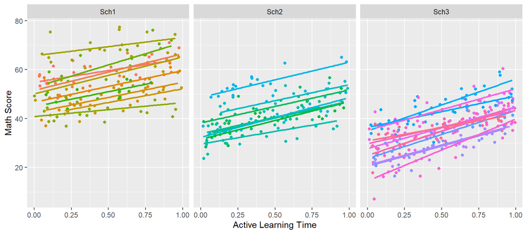

```r
last_plot() + facet_wrap(~ School)
```

# Example: Math Active Learning, School and Class Size are confounded

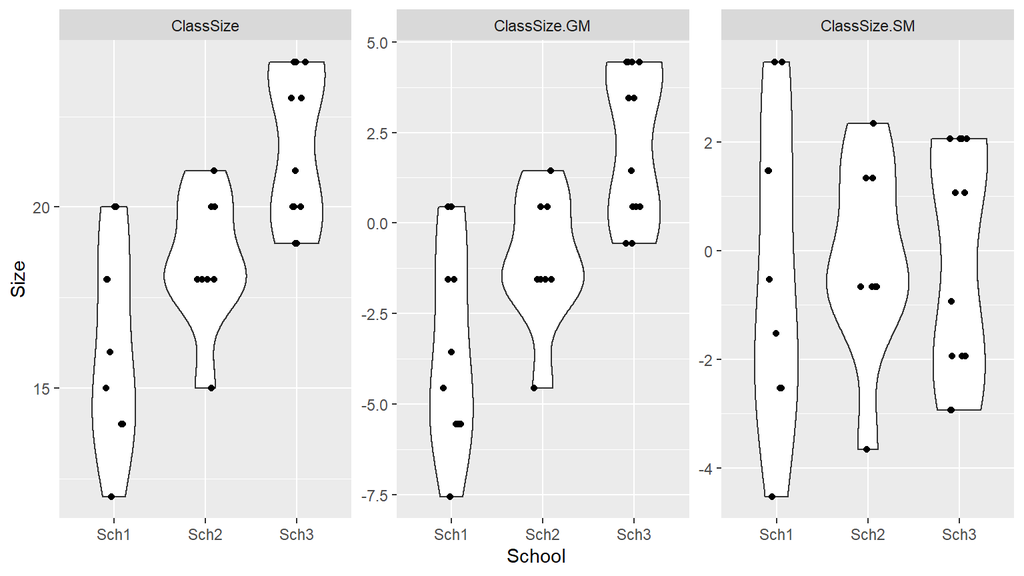

```r
unique(select(math, School, Class, ClassSize, ClassSize.GM, ClassSize.SM)) %>%
  pivot_longer(cols=starts_with("ClassSize"),
               names_to = "Type", values_to = "Size") %>%
  ggplot(aes(School, Size)) + facet_wrap(~ Type, scales="free_y") +
  geom_violin() + geom_jitter(width=0.1, height=0)
```

- As we saw before, the schools have consistently different class sizes, which means that these variables are confounded: can’t distinguish (random, uninteresting) differences between schools from (systematic, interesting) effects of class size.
- This is true for both raw and grand-mean-centered class sizes
- School-mean-centered class sizes allow testing effect of class size while controlling for school-level differences

# Sidebar: Simpson’s Paradox

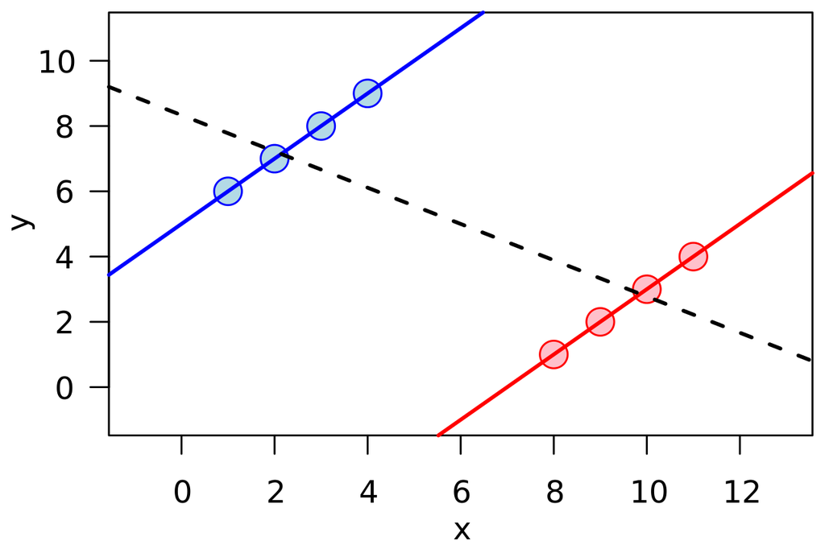

image credit: wikipedia

Famous real-world example: gender bias in PG admissions at University of California - Berkeley in 1973

- Overall acceptance rate higher for males than females
- But individual department acceptance rates higher for females than males

This is usually because of a “lurking” (confounding) variable. In the Berkeley example there is a confound between gender differences in *application* rates and *department* differences in acceptance rates: departments with low admission rates had many more female applicants, departments with higher admission rates had many more male applicants. As a result, even though (almost) all departments had higher acceptance rates for females, the *overall* acceptance rate was higher for males.

**Lesson**: watch out for sub-group (cluster-level) differences that might be confounded with your variables of interest.

# Example: Math Active Learning, 3-level model

- Use school-mean-centered measure of class size to test effect of class size while controlling for school-level differences
- Add random effect of School (intercept and slope)

```r
m3 <- lmer(Math ~ ActiveTime.GM * ClassSize.SM +
           (1 + ActiveTime.GM | School) +
           (1 + ActiveTime.GM | Class),
           data=math, REML=FALSE)
kable(tidy(m3))
```

| effect | group | term | estimate | std.error | statistic | df | p.value |
| --- | --- | --- | --- | --- | --- | --- | --- |
| fixed | NA | (Intercept) | 44.4518 | 4.6674 | 9.5239 | 3.045 | 0.0023 |
| fixed | NA | ActiveTime.GM | 14.3485 | 1.8124 | 7.9168 | 3.231 | 0.0032 |
| fixed | NA | ClassSize.SM | -0.0366 | 0.5729 | -0.0638 | 27.972 | 0.9496 |
| fixed | NA | ActiveTime.GM:ClassSize.SM | -0.7832 | 0.4133 | -1.8950 | 32.515 | 0.0670 |
| ran_pars | Class | sd__(Intercept) | 6.7440 | NA | NA | NA | NA |
| ran_pars | Class | sd__ActiveTime.GM | 3.6026 | NA | NA | NA | NA |
| ran_pars | Class | cor__(Intercept).ActiveTime.GM | 0.1246 | NA | NA | NA | NA |
| ran_pars | School | sd__(Intercept) | 7.7827 | NA | NA | NA | NA |
| ran_pars | School | sd__ActiveTime.GM | 2.7430 | NA | NA | NA | NA |
| ran_pars | School | cor__(Intercept).ActiveTime.GM | -1.0000 | NA | NA | NA | NA |
| ran_pars | Residual | sd__Observation | 3.9147 | NA | NA | NA | NA |

- Effect of Class Size is no longer significant: it was a Simpson’s paradox effect (differences between Schools, which are confounded with class size, not effects of class size)

# Example: Math Active Learning, 3-level model

With only 3 schools, the school-level random effects are probably over-parameterized…

```r
VarCorr(m3)
```

```
##  Groups   Name          Std.Dev. Corr
##  Class    (Intercept)   6.74
##           ActiveTime.GM 3.60     0.12
##  School   (Intercept)   7.78
##           ActiveTime.GM 2.74     -1.00
##  Residual               3.91
```

Yes, the slope-intercept correlation is -1.00, so remove it:

```r
m3a <- lmer(Math ~ ActiveTime.GM * ClassSize.SM +
           (1 + ActiveTime.GM || School) +
           (1 + ActiveTime.GM | Class),
           data=math, REML=FALSE)
VarCorr(m3a)
```

```
##  Groups   Name          Std.Dev. Corr
##  Class    (Intercept)   6.79
##           ActiveTime.GM 3.75     0.14
##  School   ActiveTime.GM 2.56
##  School.1 (Intercept)   7.88
##  Residual               3.91
```

```r
kable(tidy(m3a))
```

| effect | group | term | estimate | std.error | statistic | df | p.value |
| --- | --- | --- | --- | --- | --- | --- | --- |
| fixed | NA | (Intercept) | 44.3558 | 4.7275 | 9.3825 | 3.030 | 0.0025 |
| fixed | NA | ActiveTime.GM | 14.3269 | 1.7361 | 8.2526 | 3.179 | 0.0030 |
| fixed | NA | ClassSize.SM | -0.0276 | 0.5770 | -0.0479 | 27.254 | 0.9621 |
| fixed | NA | ActiveTime.GM:ClassSize.SM | -0.7793 | 0.4231 | -1.8420 | 29.970 | 0.0754 |
| ran_pars | Class | sd__(Intercept) | 6.7905 | NA | NA | NA | NA |
| ran_pars | Class | sd__ActiveTime.GM | 3.7550 | NA | NA | NA | NA |
| ran_pars | Class | cor__(Intercept).ActiveTime.GM | 0.1370 | NA | NA | NA | NA |
| ran_pars | School | sd__ActiveTime.GM | 2.5575 | NA | NA | NA | NA |
| ran_pars | School.1 | sd__(Intercept) | 7.8845 | NA | NA | NA | NA |
| ran_pars | Residual | sd__Observation | 3.9149 | NA | NA | NA | NA |

# 10-minute break

# Crossed random effects

In most statistical tests, we are evaluating the reliability of some effect in the context of the variability in the data. The goal is to make an inference from the sample to the population from which from that sample was drawn.

- Usually, we want to make inferences about reliability/variability across *subjects*: i.e., in general, do participants tend to show this effect or is it just one or two people showing it? That is, would we expect the rest of the participant population to also behave this way?
- We might also ask about reliability/variability across *items*. This often comes up in laboratory experimental contexts where we ask participants to solve N problems, or answer N questions, or recognize N words, etc. There will be variability across those N “items” and we should test whether our effects of interest are reliable in the context of that variability. That is, would we expect the same outcome for other problems, questions, words, etc. from the same population?
- Historically, this was done by conducting separate by-subjects and by-items analyses and journals sometimes even required this (a long time ago, I had a paper rejected because a key result was statistically significant by subjects but only marginal by items).
- Multilevel regression provides a better solution to this problem…

# Improving problem solving

Made-up data on an intervention to improve problem solving ability

```r
load("../data/problem_solving.Rdata")
summary(problem_solving)
```

```
##       Item      Prob_Type      Subject         Condition          RT
##  AC     : 115   Hard:1494   S101   :  30   Control  :1397   Min.   :  440
##  AV     : 109   Easy:1370   S109   :  30   Treatment:1467   1st Qu.: 1161
##  AE     : 107               S121   :  30                    Median : 1536
##  AB     : 105               S122   :  30                    Mean   : 1730
##  AH     : 102               S124   :  30                    3rd Qu.: 2040
##  AJ     : 102               S134   :  30                    Max.   :12753
##  (Other):2224               (Other):2684
```

- `Item`: word problem, can be *Hard* or *Easy*
- `Prob_Type`: difficulty level of word problem (16 hard problems, 14 easy problems)
- `Subject`: Participant ID, N=120
- `Condition`: whether the participant received the `Treatment` or not
- `RT`: time to solve the problem

Note: there is some missing data because trials where the participants failed to solve the problem are excluded.

# A traditional analysis approach

1. Calculate subject-by-condition means

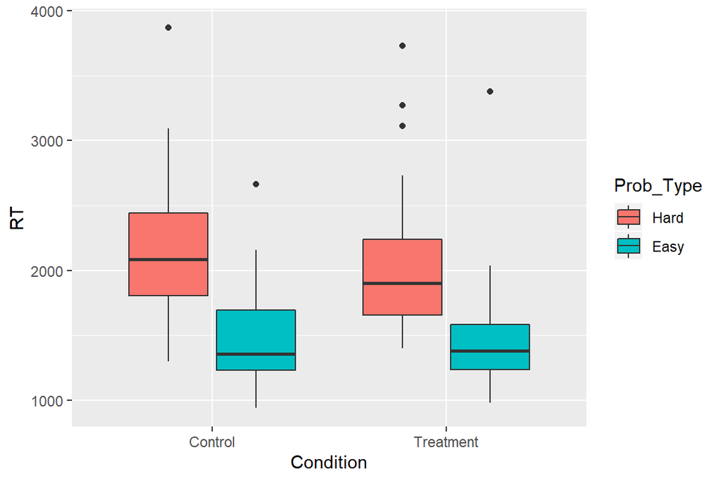

```r
ps_subj <- problem_solving %>%
  group_by(Subject, Condition, Prob_Type) %>%
  summarise(RT = mean(RT))
# plot the subject-level data
ggplot(ps_subj, aes(Condition, RT, fill=Prob_Type)) +
  geom_boxplot()
```

- Everyone solves `Easy` problems faster than `Hard` ones
- `Treatment` group seems faster at problem solving, esp. for `Hard` problems

# Repeated-measures ANOVA

```r
afex::aov_ez(id = "Subject", dv = "RT",
  within = "Prob_Type",
  between = "Condition",
  data = ps_subj)
```

```
## Contrasts set to contr.sum for the following variables: Condition
```

```
## Anova Table (Type 3 tests)
##
## Response: RT
##                Effect     df       MSE          F  ges p.value
## 1           Condition 1, 118 255247.21       2.44  .01     .12
## 2           Prob_Type 1, 118  98268.92 223.46 ***  .34  <.0001
## 3 Condition:Prob_Type 1, 118  98268.92       1.96 .005     .16
## ---
## Signif. codes:  0 '***' 0.001 '**' 0.01 '*' 0.05 '+' 0.1 ' ' 1
```

- At this point, it looks like there is an overall problem difficulty effect, and no effect(s) of the intervention.
- But hang on: not all word problems are the same and we’re going to make inferences about solving problems *of this type*, not just about solving these particular problems.

# By-items analysis

Calculate item-by-condition means

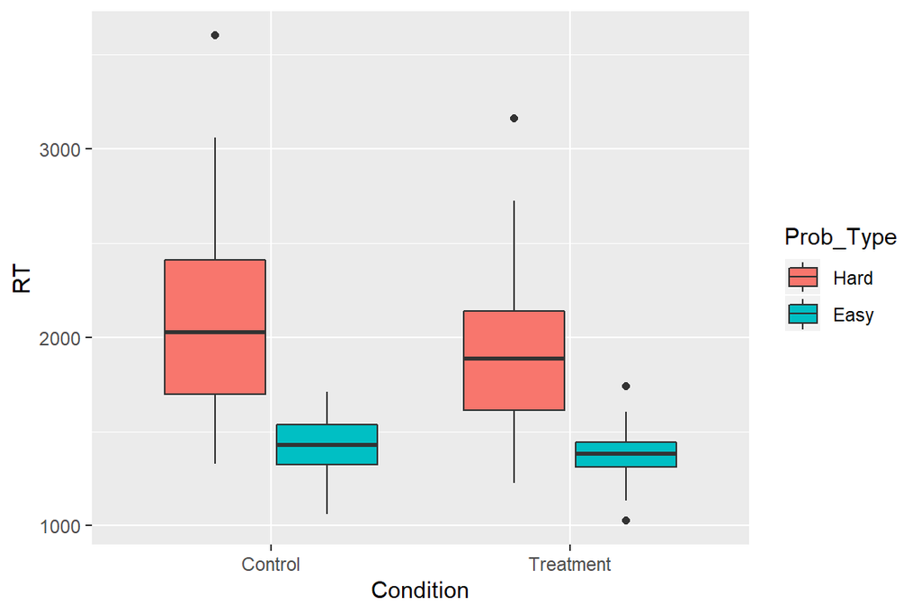

```r
ps_item <- problem_solving %>%
  group_by(Item, Condition, Prob_Type) %>%
  summarise(RT = mean(RT))
# plot the item-level data
ggplot(ps_item, aes(Condition, RT, fill=Prob_Type)) +
  geom_boxplot()
```

# By-items repeated-measures ANOVA

```r
afex::aov_ez(id = "Item", dv = "RT",
  between = "Prob_Type",
  within = "Condition",
  data = ps_item)
```

```
## Contrasts set to contr.sum for the following variables: Prob_Type
```

```
## Anova Table (Type 3 tests)
##
## Response: RT
##                Effect    df       MSE         F  ges p.value
## 1           Prob_Type 1, 28 342623.14 17.47 ***  .37   .0003
## 2           Condition 1, 28  15095.59  12.46 **  .02    .001
## 3 Prob_Type:Condition 1, 28  15095.59    5.26 * .008     .03
## ---
## Signif. codes:  0 '***' 0.001 '**' 0.01 '*' 0.05 '+' 0.1 ' ' 1
```

- All effects significant
- Hol up, why the difference?
- The effect of problem type (difficulty) is large and it is significant in both analyses
- The condition (intervention) effect and its interaction with problem type are small
- Condition is a between-subjects variable but a within-items variable, so the variability among subjects is averaged away in the by-items analysis, but in the by-subjects analysis this variability is stronger than the group-level effect of Condition and its interaction.
- One interpretation is that the effect is consistent across items, but not across subjects: some subjects show it and some don’t. This was not apparent in the by-items analysis because data were collapsed across subjects (within intervention condition) for that analysis. In other words, the effect would be expected to generalize to other problems but not to other participants, which is obviously problematic.
- However, the idea that effects should be significant in separate by-items and by-subjects analyses (aka F1 and F2) is generally thought to be overly conservative

# A multilevel regression approach

Multilevel regression provides a way to simultaneously model random variability at subject and item levels, as well as the group-level effects that we are interested in.

These data are nested (clustered observations that are not independent), but, unlike prior examples, they are not *hierarchical*. Items are clustered within subjects (subjects solved multiple problems); but also subjects are clustered within items (same problems were presented to multiple subjects). This can be modeled with *crossed random effects*.

```r
mod_ps <- lmer(RT ~ Prob_Type*Condition +
                   (Prob_Type | Subject) +
                   (Condition | Item),
                 data=problem_solving, REML=FALSE)
```

```
## boundary (singular) fit: see ?isSingular
```

```r
summary(mod_ps)
```

```
## Linear mixed model fit by maximum likelihood . t-tests use Satterthwaite's
##   method [lmerModLmerTest]
## Formula: RT ~ Prob_Type * Condition + (Prob_Type | Subject) + (Condition |
##     Item)
##    Data: problem_solving
##
##      AIC      BIC   logLik deviance df.resid
##    46245    46311   -23112    46223     2853
##
## Scaled residuals:
##    Min     1Q Median     3Q    Max
## -2.835 -0.543 -0.110  0.364 12.301
##
## Random effects:
##  Groups   Name        Variance Std.Dev. Corr
##  Subject  (Intercept)  74023   272.1
##           Prob_Type1    8912    94.4    1.00
##  Item     (Intercept) 153298   391.5
##           Condition1    1391    37.3    1.00
##  Residual             541953   736.2
## Number of obs: 2864, groups:  Subject, 120; Item, 30
##
## Fixed effects:
##                       Estimate Std. Error     df t value Pr(>|t|)
## (Intercept)             1753.5       77.2   37.3   22.73  < 2e-16 ***
## Prob_Type1               325.2       73.5   30.9    4.43  0.00011 ***
## Condition1                58.3       29.4  111.6    1.98  0.04989 *
## Prob_Type1:Condition1     36.1       17.7   86.8    2.04  0.04461 *
## ---
## Signif. codes:  0 '***' 0.001 '**' 0.01 '*' 0.05 '.' 0.1 ' ' 1
##
## Correlation of Fixed Effects:
##             (Intr) Prb_T1 Cndtn1
## Prob_Type1  -0.023
## Condition1   0.217 -0.015
## Prb_Typ1:C1 -0.024  0.379  0.398
## convergence code: 0
## boundary (singular) fit: see ?isSingular
```

# Plotting results

Computing means and SE is a little tricky for trial-level data

Conveniently, the `effects` package will do that based on the fitted model

```r
library(effects)
ef <- effect("Prob_Type:Condition", mod_ps)
summary(ef)
```

```
##
##  Prob_Type*Condition effect
##          Condition
## Prob_Type Control Treatment
##      Hard    2173      1984
##      Easy    1450      1406
##
##  Lower 95 Percent Confidence Limits
##          Condition
## Prob_Type Control Treatment
##      Hard    1937      1780
##      Easy    1214      1207
##
##  Upper 95 Percent Confidence Limits
##          Condition
## Prob_Type Control Treatment
##      Hard    2410      2189
##      Easy    1686      1605
```

```r
efx <- as.data.frame(ef)
efx
```

```
##   Prob_Type Condition  fit    se lower upper
## 1      Hard   Control 2173 120.5  1937  2410
## 2      Easy   Control 1450 120.4  1214  1686
## 3      Hard Treatment 1984 104.2  1780  2189
## 4      Easy Treatment 1406 101.4  1207  1605
```

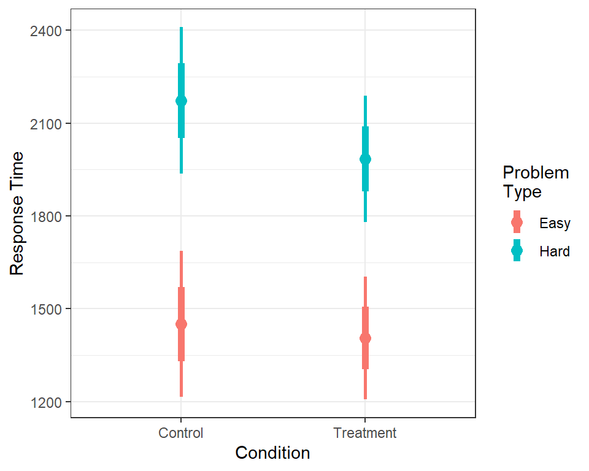

```r
ggplot(efx, aes(Condition, fit, color=Prob_Type)) +
  geom_point(size=3) +
  geom_linerange(aes(ymin=fit-se, ymax=fit+se), size=2) +
  geom_linerange(aes(ymin=lower, ymax=upper), size=1) +
  theme_bw() +
  labs(y="Response Time", color="Problem\nType")
```

# Not so different after all

Today’s lecture covered some more complex random effect structures

- 3-level nesting
- Crossed random effects

These are just kinds of MLR and the principles from other lectures also apply to these analyses

- p-value (df) estimation using Satterthwaite method; model comparisons would’ve been a good alternative
- use full random effect structure, where “full” is defined by study design; can simplify if model doesn’t converge by removing correlations and random “slopes”
- be aware of how your categorical variables as coded; can conduct pairwise comparisons using a single model
- use logistic regression for binary outcomes
- can use random effects to quantify individual differences (next lecture)